# DEP analysis without imputation for the CPTAC dataset

Ludger Goeminne

29-11-2019

# Analysis of the Differential Enrichment analysis of Proteomics data (DEP) workflow without imputation for the CPTAC dataset based on LFQ-summarized data

We base ourselves on the DEP vignette: https://bioconductor.org/packages/devel/bioc/vignettes/DEP/inst/doc/DEP.html.

For the mixed imputation, we based ourselves on this DEP vignette: https://bioconductor.org/packages/release/bioc/vignettes/DEP/inst/doc/MissingValues.html#mixed-imputation-on-proteins-rows

Set working directory and load all necessary libraries and functions.

```r
# If not installed, install and load the package "here", else: only load the package.
err <- try(library("here", character.only = TRUE), silent = TRUE)
```

```
## here() starts at /Users/lgoeminn/Documents/phD/MSqRobHurdlePaper
```

```r
if (class(err) == 'try-error') {
  install.packages("here", repos = "https://cloud.r-project.org")
  library("here", character.only = TRUE)
}

wd <- here()

# Optional: change the working directory
setwd(wd)

# Load all functions and libraries
source(paste0(wd, "/R/functions.r"))
```

```
##
## This is MSnbase version 2.8.3
##   Visit https://lgatto.github.io/MSnbase/ to get started.
```

```r
source(paste0(wd, "/R/DEP.r"))
```

Important: make sure you have run 1_analysis_CPTAC_MSqRob.Rmd OR load `peptides.CPTAC` via:

```r
load(paste0(wd, "/save_files_CPTAC/peptides_CPTAC.RData"))
```

## 1. Data import and preprocessing

1. **Important:** in the CPTAC dataset, some human UPS proteins are NOT contaminants as these proteins were spiked in on purpose! We only want to remove those contaminants that are not humane UPS proteins. We thus need to unmark these proteins as contaminant before preprocessing.

The following two proteins were manually indicated as not being contaminants in Perseus by removing their corresponding `"+"` symbol in the `"Potential contaminants"` column:

P06396ups;CON__Q3SX14

P02768ups;CON__P02768-1

We saved the new file as **`"proteinGroups_cont_curated.txt"`** (see 6_analysis_CPTAC_Perseus.Rmd).

```r
dataset.CPTAC <- read.table(paste0(wd, "/datasets/CPTAC/proteinGroups_cont_curated.txt"), sep="\t", quote="", comment.char = "", header=TRUE)
```

We filter for contaminant proteins, decoy database hits and proteins which are only identified by modified peptides. These are indicated by “+” in the columns “Potential.contaminants”, “Reverse” and “Only.identified.by.site”, respectively.

```r
dataset.CPTAC <- dplyr::filter(dataset.CPTAC, Reverse != "+", Potential.contaminant != "+", Only.identified.by.site != "+")
```

Some gene names are duplicated, but this is not relevant for the CPTAC dataset, because here we will work with Uniprot identifiers:

```r
dataset.CPTAC$Gene.names %>% duplicated() %>% any()
```

```
## [1] TRUE
```

```r
# TRUE

# No duplicated protein IDs, as expected
dataset.CPTAC$Protein.IDs %>% duplicated() %>% any()
```

```
## [1] FALSE
```

```r
# FALSE

dataset.CPTAC <- DEP::make_unique(dataset.CPTAC, "Protein.IDs", "Protein.IDs", delim = ";")
```

```r
experimental.design <- data.frame(label = peptides.CPTAC %>% sampleNames %>% as.character, condition = peptides.CPTAC %>% sampleNames %>% substr(2,3) %>% as.character, replicate = c("LTQ-Orbitrap_86" %>% rep(3), "LTQ-OrbitrapO_65" %>% rep(3), "LTQ-OrbitrapW_56" %>% rep(3)) %>% rep(3) %>% as.character, stringsAsFactors = FALSE)

LFQ.columns <- grep("LFQ.", colnames(dataset.CPTAC)) # get LFQ column numbers
data.se <- make_se2(dataset.CPTAC, LFQ.columns, experimental.design)
```

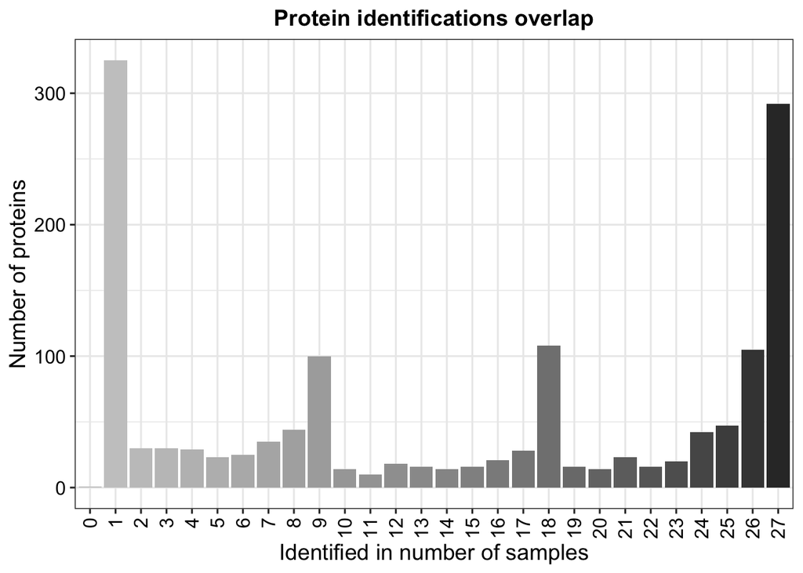

```r
# Plot a barplot of the protein identification overlap between samples
# To be expected: some proteins are only found in certain labs
plot_frequency(data.se)
```

No filtering, because filtering makes the performance of DEP even worse.

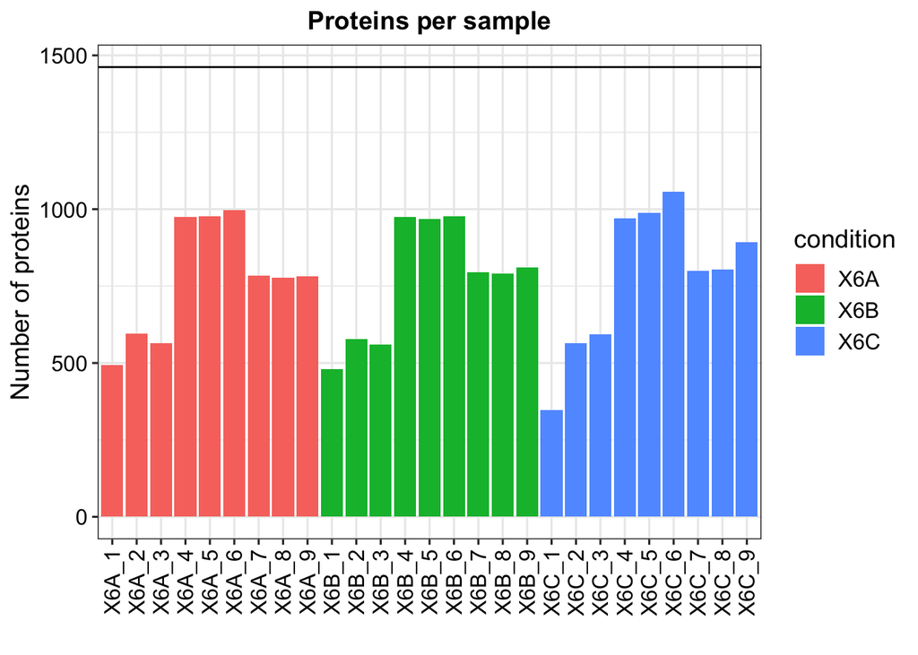

```r
# Plot a barplot of the number of identified proteins per samples
plot_numbers(data.se)
```

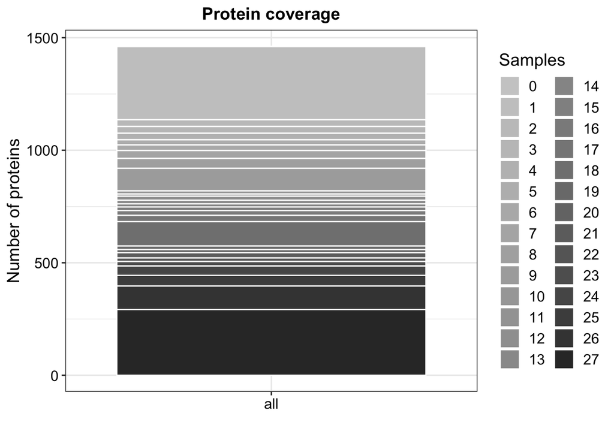

```r
# Plot a barplot of the protein identification overlap between samples
plot_coverage(data.se)
```

Background correction and normalization by variance stabilizing transformation (vsn).

```r
# Normalize the data
data.norm <- normalize_vsn(data.se)
```

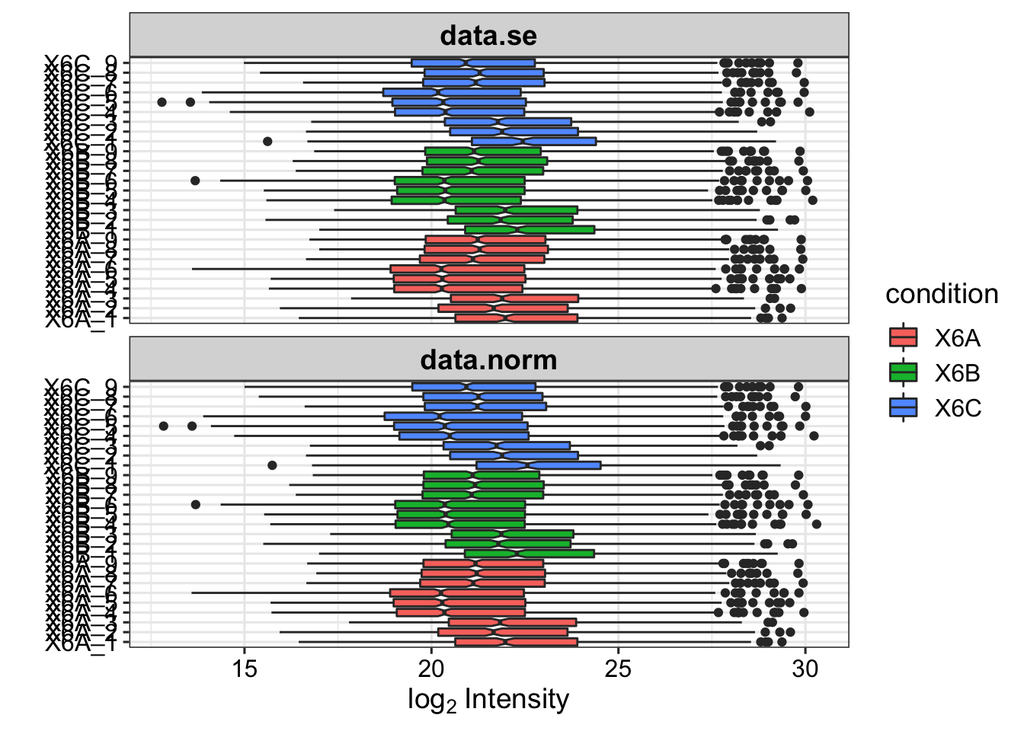

```r
# Visualize normalization by boxplots for all samples before and after normalization
plot_normalization(data.se, data.norm)
```

Here, we do not impute data for missing values.

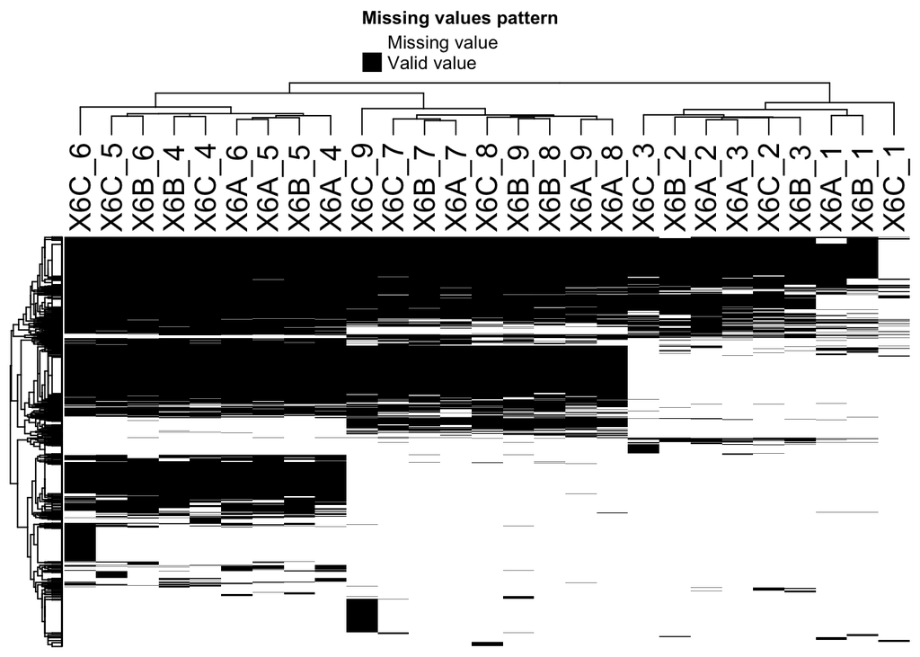

```r
# Plot a heatmap of proteins with missing values
plot_missval(data.norm)
```

```r
# The huge lab-effect is visible in the heatmap!
```

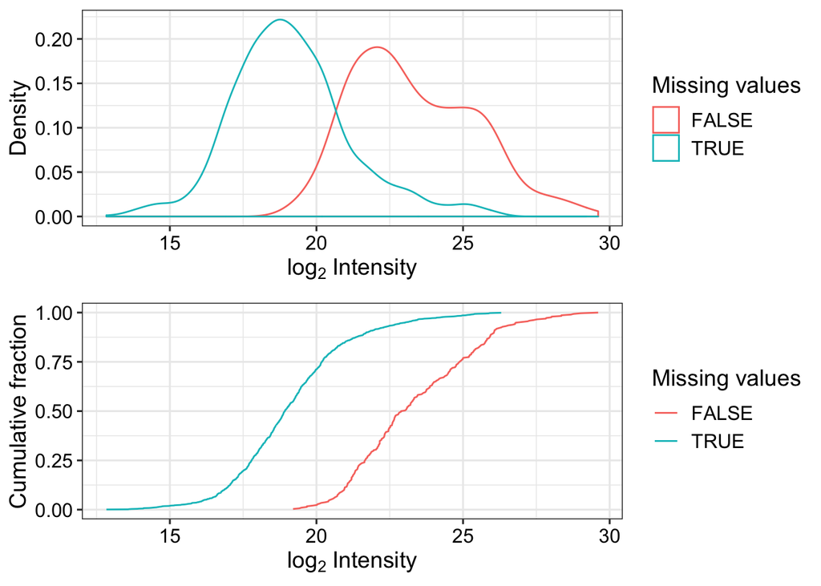

```r
# Plot intensity distributions and cumulative fraction of proteins with and without missing values
plot_detect(data.norm)
```

## Differential enrichment analysis

```r
# Test all possible comparisons of samples
data_diff_all_contrasts <- DEP::test_diff(data.norm, type = "all")
```

```
## Tested contrasts: X6A_vs_X6B, X6A_vs_X6C, X6B_vs_X6C
```

```r
dep <- add_rejections(data_diff_all_contrasts, alpha = 0.05, lfc = 0)
res <- get_results(dep)


res.CPTAC.DEP.noimp <-  res %>%
    gather(statistic,value, contains('_vs_')) %>%
    mutate(statistic = str_replace(statistic, "_vs_",'vs')) %>%
    separate(statistic,c('contrast', 'statistic'),sep = '_') %>%
    spread(statistic,value) %>%
    transmute(protein = ID
            , feature = ID
              ## contrasts are differently specified
            , logFC = -ratio
            , pvalue = p.val
            , qvalue = p.adj
            , contrast) %>%
    separate(contrast, c('sample2', 'sample1'),sep = 'vs') %>%
    mutate(contrast = str_glue('{sample1}-{sample2}')) %>%
    as_data_frame
res.CPTAC.DEP.noimp$UPS <- grepl("ups", res.CPTAC.DEP.noimp$protein)
res.CPTAC.DEP.noimp <- res.CPTAC.DEP.noimp[, c("protein", "UPS", "contrast", "logFC", "pvalue", "qvalue")]
res.CPTAC.DEP.noimp$protein <- gsub("\\\"", "", res.CPTAC.DEP.noimp$protein)
res.CPTAC.DEP.noimp <- res.CPTAC.DEP.noimp %>% arrange(pvalue)

res.CPTAC.DEP.noimp$contrast[res.CPTAC.DEP.noimp$contrast == "X6B-X6A"] <- "condition6B-condition6A"
res.CPTAC.DEP.noimp$contrast[res.CPTAC.DEP.noimp$contrast == "X6C-X6A"] <- "condition6C-condition6A"
res.CPTAC.DEP.noimp$contrast[res.CPTAC.DEP.noimp$contrast == "X6C-X6B"] <- "condition6C-condition6B"

# Or load the results:
# load(paste0(wd, "/save_files_CPTAC/res_CPTAC_DEP_noimp.RData"))
```